# 04_fires_unify_wumi3

Author

Tyler L. McIntosh

Published

May 14, 2025

# Overview & Takeaways

This code takes the WUMI 3 data compiled by Park Williams and creates a unified fire perimeter dataset for use in WFFRC’s activities.

# Data overview

Information from Park for users of the WUMI3 dataset are as follow:

“The text file called multiproduct_unique_fires.txt has a list of all the main fires in the database. I say *main* fires because a number of large fires in this list of *main* fires are complex fires that are composed of smaller fires. For our fire modeling, I try whenever possible to decompose complex fires into their smaller components, but the exact sizes and boundaries of those smaller components are uncertain…

Each row in the list of main fires corresponds to a single fire event. The first element in each row is an ID number that I’ve assigned to that fire (YYYYMMDD_LAT_LON). For each of these fires, you can find the corresponding map of 1-km fractional burned area (netcdf) and fire perimeter (shape file) in the subdirectory called FireMaps/.

For each fire, there are number of maps. For each fire, I make an initial pair of .nc and .shp files called “burnarea_circle.nc” and “burnarea_circle.shp” where I simply characterize the area burned as a perfect circle centered on the ignition coordinates. But when better data are available, then I also produce other pairs of maps:

- For fires with MTBS data, I also make files called burnarea_mtbs.
- For fires with CalFire data, I also make files called burnarea_calfire.
- For fires with NIFC data, I also make files called burnarea_nifc.
- For fires with GEOMAC data, I also make files called burnarea_geomac.

It’s conceivable that some fires could have pairs of .nc and .shp files for all of the above datasets.

What I recommend is for each fire you prioritize the burned-area / perimeter files in the following order:

- MTBS whenever available CalFire if MTBS is not available
- NIFC if neither of the above is available
- GEOMAC if none of the above are available
- Circle if none of the above area available”

## A full description of WUMI 3 from Park’s paper

“To parameterize the fire model we produce version 3 of the Western US MTBS-Interagency (WUMI3) dataset of observed wildfires ≥1 km2 in area, which covers 1985–2024 (REF). This is a revision and update of the WUMI2 (Juang & Williams, 2024), which covered 1984–2020. We exclude 1984 here because of a suspicious absence of fires in the states of Wyoming and New Mexico in that year. Like the WUMI3, the WUMI2 is developed by merging a number of publicly US government sources. Here we describe each database used for the WUMI3 and then how they were merged.

1. MTBS (https://www.mtbs.gov/): The US Forest Service Monitoring Trends in Burn Severity (MTBS) project (Eidenshink et al., 2007) maintains a database of landsat-based maps of burned areas at 30-m resolution for large (>4.04 km2) fires spanning 1984–2024, though records for 2023 and 2024 were incomplete at the time of access (Mar 4 2025). The MTBS dataset distinguishes four fire types: wildfires, prescribed fires, wildland fire use fires, and unknown. We excluded prescribed fires.
2. FPA-FOD (https://doi.org/10.2737/RDS-2013-0009.6): The US Forest Service’s Fire Program Analysis Fire-Occurrence Database (FPA-FOD) (Short, 2022) is a list of fire incidents addressed by a number of government agencies from 1992–2020.
3. WFAIP (https://www.wildfire.gov/page/zip-files): The Wildland Fire Application Portal (WFAIP) hosts a lists of fire incidents addressed by the US Forest Service and Fish and Wildlife Service from 1972–2020 and by the Bureau of Land Management, Bureau of Indian Affairs, Bureau of Reclamation, and National Park Service from 1972–2017. We limited these records to 1985–1991, as the FPA-FOD dataset, which becomes available in 1992, is more thoroughly documented. Comparison of annual records of fire frequency and area burned calculated from the WFAIP and FPA-FOD datasets indicates strong agreement from 1992 through the early 2000s and then reductions in fire frequencies and areas burned from WFAIP relative to FPA-FOD, suggesting a reduction in the completeness of the WFAIP dataset throughout the 2000s.
4. CalFire (https://www.fire.ca.gov/what-we-do/fire-resource-assessment-program/fire-perimeters): The California Department of Forestry and Fire Protection (CalFire) Resource Assessment Program (FRAP) maintains a database of perimeters for fire incidents in California. The first fire represented in the CalFire FRAP dataset occurred in 1898 and the current version (last accessed Mar 4 2025) comes through 2023. The criteria that CalFire Frap uses to determine whether to include a given fire in the database include fire size and damages. These criteria have changed over time but for the relatively large ≥1 km2 fires of interest during our post-1985 study period the policy has been to record all possible fires. CalFire does not provide ignition locations in the FRAP database so we estimate each fire’s ignition location as the central latitude and longitude coordinates within each fire boundary.
5. NIFC (https://data-nifc.opendata.arcgis.com/datasets/nifc::wfigs-interagency-fire-perimeters/about): The National Interagency Fire Center (NIFC) maintains a database of fire perimeters mapped by the Wildland Fire Interagency Geospatial Services Group. These perimeters are for wildland fire incidents that have been categorized with an Integrated Reporting of Wildland Fire Information identification code (IRWIN ID). The first fire in this database occurred in 2018 and is updated in real-time, but the records prior to 2021 are incomplete (accessed Feb 21 2025).
6. GeoMAC (https://data-nifc.opendata.arcgis.com/datasets/nifc::historic-perimeters-combined-2000-2018-geomac/about): The NIFC maintains a database of fire perimeters mapped by the Geospatial Multi-Agency Coordination Group (GeoMAC) for wildfires that occurred from 2000–2018. The GeoMAC dataset only provides the year of fire occurrence, but not day of year.

For all non-MTBS datasets described above, we remove fires <1 km2 in area as well as fires with RX, PSBURN, PRESCRIBE, or CONTROL BURN in the name, as these are highly likely to be prescribed fires. We further remove fires with ASSIST, ASST, or AST in the name, as these fires are likely cases in which one agency assisted another agency’s suppression effort that was recorded more completely by that other agency. Finally, we remove duplicate entries in which multiple fires occurred at the same location with the same size on the same date. We also identify duplicates as multiple fires that occurred within 5 days, share an identical name, and are within 200 km of each other (reported fire locations are often imprecise or inaccurate). We allow for flexibility in searching for identical names, including not necessitating identical punctuation (e.g., “.” or “#”) and allowing for abbreviations (e.g., “MOUNTAIN” vs “MT” or “CANYON” vs “CYN”). If a fire’s full name is within the name of another fire, we interpret them to be duplicates if they are within 5 days and 50 km. Among pairs of fires with an UKNOWN name, we identify fires as duplicates if they are within 25 km, 3 days, and 10% of the larger of the fire sizes. If these criteria are met between a pair of fires but just one fire’s name is UNKWOWN, the fires are considered duplicates if they are within 1 day of each other. In all cases of identical duplicates, we keep the first that appears in the database and discard any others. In cases of likely but not identical duplicates, we prioritize the fire with the earlier discovery date if dates differ and then the fire with the larger area if sizes differ and discard the others. Finally, for NIFC, GeoMac, and CalFire, for which fire boundaries are available, we identify pairs of fires within the same dataset that have a listed discovery date 14 days and for which ≥50% of one fire’s boundary is contained within another’s. For WFIGS and FPA-FOD, we do the same assuming fires are circular centered on the provided latitude/longitude coordinate pair and with the provided area. After automated quality control we used visual inspection of the fire lists and maps of fire locations to identify additional duplicates and as well as cases in which fire dates, locations, or names are clearly incorrect and can be confidently revised.

To develop our final dataset of 1985–2024 wildfires ≥1 km2 from the above datasets, we begin by developing a master set of non-MTBS fires from WFAIP, FPA-FOD, NIFC, and CalFire, to then be merged with the MTBS dataset. Our first step is to merge CalFire with WFAIP for 1985–1991, FPA-FOD for 1992–2020, and NIFC for 2021–2023, prioritizing CalFire when possible. For NIFC, most matches to CalFire fires are easily identified due to common IRWIN IDs. We additionally assume a non-CalFire fire to be a match to a given CalFire fire if it has the same name, has a start-date within 5 days of the CalFire discovery date, and is located within 1.5° of the bounding box of the CalFire boundaries. For CalFire fires with UNKNOWN name and cases of non-matching names, we consider a non-CalFire fire to be a match with or part of a CalFire fire if it is within 5 days and 0.1° of the CalFire bounding box. We additionally identify NIFC fires as duplicates of, or part of, CalFire fires if their listed discovery dates were within 5 days and have overlapping boundaries. Some CalFire fires represent fire complexes made of multiple fires that began separately and merged. In cases where multiple non-CalFire fires are identified as matches to a given CalFire fire, we manually inspect and if multiple fires appear to have indeed contributed to the CalFire fire we save this information for later use rather than discarding the non-CalFire fires.

We next merge this non-MTBS dataset with MTBS. That is, we identify likely matches between non-MTBS and MTBS fires as well as MTBS fires that appear to contain multiple smaller non-MTBS fires. In all cases we prioritize the spatial information about area burned from MTBS because this is the only dataset to provide high-resolution (30 m) within-fire maps of area burned. For NIFC, it is straight-forward to identify matches to MTBS fires by comparing IRWIN IDs. In addition, in producing the FPA-FOD dataset, Short (2022) identified many matches to MTBS fires and provided linkages to the corresponding MTBS Fire ID. After using IRWIN IDs (and MTBS Fire IDs in the case of FPA-FOD fires), we identify additional matches between MTBS and non-MTBS fires using similar, methods as those described above to merge non-CalFire and CalFire fires, though for the MTBS merge we used somewhat more liberal criteria to identify matching fires. There are two reasons for this: First, MTBS fires are exclusively large fires, and are therefore more likely than CalFire fires to represent fire complexes. Second, MTBS fire footprints are identified by comparing a satellite image of the land surface in the weeks or months after the fire to a corresponding image from approximately a year prior to the fire, making it possible that the burned area attributed to a given MTBS fire was actually burned by multiple fires. After linking non-MTBS and MTBS fires using IRWINIDs and linkages made previously by Short (2022), we link a non-MTBS fire to an MTBS fire they share the same, have discovery dates within 14 days of each other, and if the non-MTBS fire’s location is within 1.5° of the MTBS fire’s bounding box. We next linked non-MTBS and MTBS fires, regardless of name, if the discovery dates are within 5 days and the non-MTBS fire’s location is be within 0.1° of the MTBS bounding box. Additionally, we link NIFC and CalFire fires to MTBS fires if the discovery dates are within 14 days and have overlapping boundaries.

Next, although the NIFC database is incomplete prior to 2021, it still contains maps of boundaries for a large number of fires from 2018–2020. When possible, we replace FPA-FOD fires with matching NIFC fires during their 2018–2020 period of overlap. An FPA-FOD fire is identified as a match to a NFIC fire if it shares the same name, has a discovery date within 14 days, and is located within 0.25° of the NIFC fire. In the case of matching UNKNOWN fire names, the PFA-FOD fire must be within 10% of the NIFC fire size. If multiple PFA-FOD fires are identified as potentially matched to a given NIFC fire, only the fire closest in size is considered to be the match. After this we do the same for GeoMAC, replacing FPA-FOD fires during 2000–2018 with the data from corresponding GeoMAC fires when possible given that the GeoMAC dataset also includes fire boundaries. In the case of GEOMAC, discovery date is not available so temporal criterion to match with an FPA-FOD fire is a shared discovery year.

For each MTBS and non-MTBS fire in the WUMI3, including non-MTBS fires linked to an MTBS fire, we produce a 1-km resolution map of fractional area. For MTBS fires, this is done by, for each 1-km grid cell, adding up the area of all 30-m grid cells identified as burned in the original MTBS dataset. For CalFire, NIFC, and GeoMAC, which provide polygons of fire boundaries, we find the area of each 1-km grid cell that falls within each burned area polygon. For WFAIP and FPA-FOD, which only provide a single latitude-longitude pair per fire, we estimate area burned boundaries by assuming the fires are circular centered on the provided coordinates and then map area burned on a 1-km grid as we did for the other datasets.

Finally, we estimate forest area burned by each fire in the WUMI3 and only retain fires that burned ≥1 km2 of forest area. To estimate the forest area burned by each fire, we overlay each fire’s burned-area map on the 1-km map of fractional forest area described Section 2, multiply to produce a map of forest area burned, and sum. We also store away the location coordinates of the central 1-km grid cell where forest burned to represent each forest fire’s occurrence. In cases where multiple non-MTBS fires are identified as part of the same MTBS fire, we adjusted each non-MTBS fire’s forest area burned proportionally so that they sum to that of the MTBS fire. If the forest-fire coordinates of a non-MTBS fire that was linked to an MTBS fire do not fall within the forest area burned indicated in the MTBS fire’s map, we reassigned the coordinates of the non-MTBS fire’s forest-fire location the nearest location with MTBS forest area burned. We also followed these final two steps in cases where multiple non-CalFire fires were linked to the same CalFire fire.”

# Setup

```r
if(!requireNamespace("here", quietly = TRUE)) {
  install.packages("here")
}
library(here)

source(here::here("code", "functions.R"))

install_and_load_packages(c("sf",
                            "here",
                            "httr",
                            "purrr",
                            "glue",
                            "tidyverse"))
```

```
All specified packages installed and loaded.
```

```r
dir_raw <- here::here("data", "raw")
dir_derived <- here::here("data", "derived")
dir_ensure(c(dir_raw,
           dir_derived))
```

# Unzip data and load main fires

```r
##########################################################
# USER-SET PARAMETER; change to most recent WUMI dataset
wumi_zip <- "WUMI_20250509.zip"
##########################################################
wumi_base <- tools::file_path_sans_ext(wumi_zip)

wumi_zip <- here::here(dir_raw, "WUMI_20250509.zip")
wumi_unzipped <- safe_unzip(zip_path = wumi_zip,
                       extract_to = dirname(wumi_zip),
                       recursive = FALSE,
                       keep_zip = TRUE,
                       return_all_paths = FALSE,
                       full_contents_check = FALSE)
```

```
Skipping unzip: Extraction target(s) already exist in C:/Users/tyler/OneDrive - UCB-O365/dev/operational-numbers-on-good-fire/data/raw
```

```r
wumi_main_fires <- readr::read_csv(file = here::here(wumi_unzipped, "multiproduct_unique_fires.txt"),
                                   show_col_types = FALSE)
```

# Primary operating functions

```r
prioritize_wumi_perimeter <- function(id) {

  ba_mtbs_file <- here::here(wumi_unzipped, "FireMaps", id, "burnarea_mtbs.shp")
  ba_calfire_file <- here::here(wumi_unzipped, "FireMaps", id, "burnarea_calfire.shp")
  ba_nifc_file <- here::here(wumi_unzipped, "FireMaps", id, "burnarea_nifc.shp")
  ba_geomac_file <- here::here(wumi_unzipped, "FireMaps", id, "burnarea_geomac.shp")
  ba_circle_file <- here::here(wumi_unzipped, "FireMaps", id, "burnarea_circle.shp")

  priority_file <- ""

  if(file.exists(ba_mtbs_file)) {
    priority_file <- ba_mtbs_file
  } else if(file.exists(ba_calfire_file)) {
    priority_file <- ba_calfire_file
  } else if(file.exists(ba_nifc_file)) {
    priority_file <- ba_nifc_file
  } else if(file.exists(ba_geomac_file)) {
    priority_file <- ba_geomac_file
  } else {
    priority_file <- ba_circle_file
  }

  return(priority_file)
}


load_file_add_dats <- function(prioritized_file) {
  p_file_name <- basename(prioritized_file)
  perimeter_type <- switch(p_file_name,
                           "burnarea_mtbs.shp" = "MTBS",
                           "burnarea_calfire.shp" = "CALFIRE",
                           "burnarea_nifc.shp" = "NIFC",
                           "burnarea_geomac.shp" = "GEOMAC",
                           "burnarea_circle.shp" = "CIRCLE",
                           NA)
  p <- sf::st_read(prioritized_file,
                   quiet = TRUE) |>
    dplyr::mutate(perimeter_type = perimeter_type,
                  fire_year = lubridate::year(date)) |>
    sf::st_set_crs("ESRI:102039")
  return(p)
}
```

# Use primary operating functions

```r
ids <- wumi_main_fires$fireid
#ids <- ids[1:1000]

# Use functions and rename since columns got shortened in .shp export from Park
prioritized_perims <- ids |>
  purrr::map(prioritize_wumi_perimeter) |>
  purrr::map(load_file_add_dats) |>
  dplyr::bind_rows() |>
  dplyr::rename(poly_area_ha = poly_area_h,
                burn_area_ha = burn_area_h,
                object_ID_interagency = object_ID_i,
                object_ID_short = object_ID_s,
                object_ID_nifc = object_ID_n,
                object_ID_calfire = object_ID_c,
                object_ID_geomac = object_ID_g,
                cause_human_or_natural = cause_human,
                cause_specific = cause_speci)
```

# Get some basic stats for user

```r
# Total events by perimeter_type
event_count <- prioritized_perims |>
  sf::st_drop_geometry() |>
  dplyr::group_by(perimeter_type) |>
  dplyr::summarise(number_of_events = n())
event_count
```

```
# A tibble: 5 × 2
  perimeter_type number_of_events
  <chr>                     <int>
1 CALFIRE                    1653
2 CIRCLE                     8608
3 GEOMAC                       82
4 MTBS                      10736
5 NIFC                       1083
```

```r
# Total area by perimeter_type
area_totals <- prioritized_perims |>
  sf::st_drop_geometry() |>
  dplyr::group_by(perimeter_type) |>
  dplyr::summarise(total_area = sum(poly_area_ha))
area_totals
```

```
# A tibble: 5 × 2
  perimeter_type total_area
  <chr>               <dbl>
1 CALFIRE           761240.
2 CIRCLE           2467700.
3 GEOMAC            112170.
4 MTBS            48395916.
5 NIFC             1348900.
```

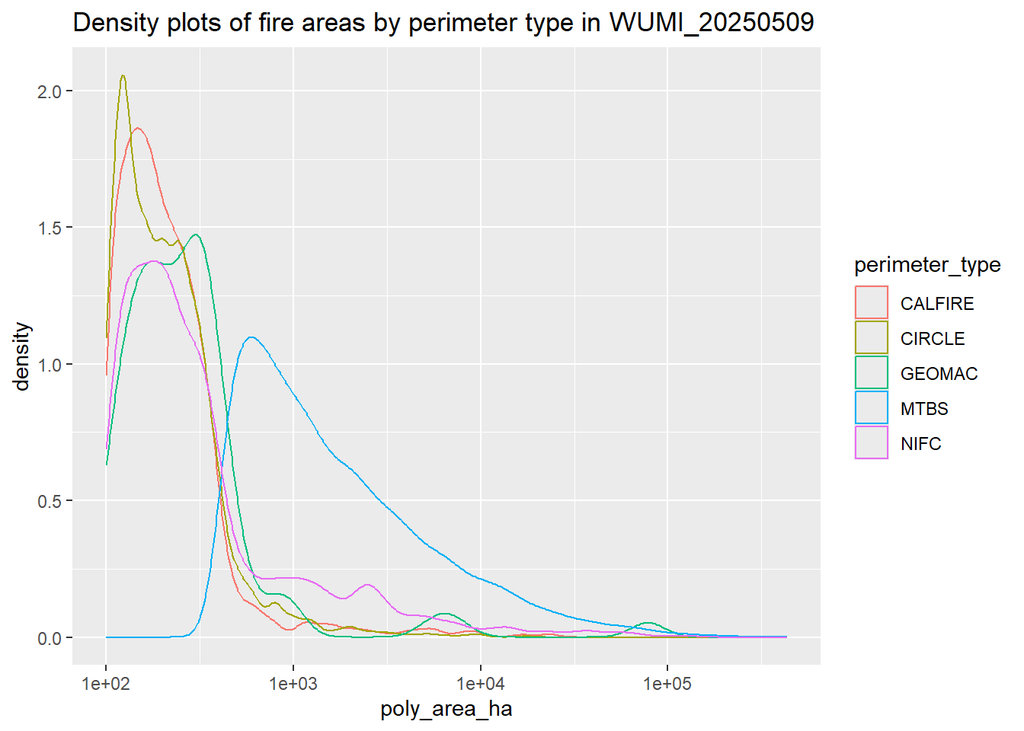

```r
# Area density by perimeter type
ggplot() +
  geom_density(data = prioritized_perims,
                 aes(x = poly_area_ha, color = perimeter_type)) +
  labs(title = glue::glue("Density plots of fire areas by perimeter type in {wumi_base}")) +
  scale_x_log10()
```

```r
# Total perimeters
print(glue::glue("There are {nrow(prioritized_perims)} events in the total {wumi_base} unified main fire set."))
```

```
There are 22162 events in the total WUMI_20250509 unified main fire set.
```

# Write out

```r
sf::st_write(prioritized_perims,
             here::here(dir_derived, glue::glue("{wumi_base}_main_fires_unified.gpkg")),
             append = FALSE)
```

```
Deleting layer `WUMI_20250509_main_fires_unified' using driver `GPKG'
Writing layer `WUMI_20250509_main_fires_unified' to data source
  `C:/Users/tyler/OneDrive - UCB-O365/dev/operational-numbers-on-good-fire/data/derived/WUMI_20250509_main_fires_unified.gpkg' using driver `GPKG'
Writing 22162 features with 23 fields and geometry type Unknown (any).
```